# Technical Assignment

Roshan Shafiha

6/29/2021

## Aim

Identify chromosome location that could differentiate the samples into north and south.

## Approach taken

Identified important features through PCA and univariate wilcoxon test. Extracted the intersecting features between them and created complexheatmap to visualize the correlation between the selected features and samples.

## Code

load the required library to run the script

```r
library("tidyr")
library("ggplot2")
library("tibble")
library("ComplexHeatmap")
library("FactoMineR")
```

load the dataset

```r
data.1<-read.csv("exercise_data.csv",header = T)

#merge the chromosome and position columns

data.2<- data.1 %>%
  unite("chromosome", Chromosome:Position, sep= "-",
        remove = T)

data.2<- data.frame(data.2[,-1], row.names=data.2[,1])

head(data.2)
```

```
##          Sample1.A Sample1.B Sample2.A Sample2.B Sample3.A Sample3.B Sample4.A
## chra-6           0        17        10        17         2        30        19
## chra-167        10        10         8        14        15        16         2
## chra-249        19         1        10        16         8         0         1
## chra-288        10         9        13         0         0        20         7
## chra-329        13        15         0         1         3        11         4
## chra-633         5         7         5        12        15         3        14
##          Sample4.B Sample5.A Sample5.B Sample6.A Sample6.B
## chra-6           0         1         0        13         9
## chra-167        15        14         2         6         0
## chra-249         0         9         0        18         8
## chra-288        15         8         0         8        12
## chra-329        18        18         4         6        12
## chra-633         4        10         1         8         1
```

```r
dim(data.2)
```

```
## [1] 1100   12
```

create the metadata that assigns the samples to its location

```r
samples<-colnames(data.2)

location<-c("north","north","north","north","north","north","south","south","south","south","south","south")

metadata<-data.frame(samples,location)

head(metadata)
```

```
##     samples location
## 1 Sample1.A    north
## 2 Sample1.B    north
## 3 Sample2.A    north
## 4 Sample2.B    north
## 5 Sample3.A    north
## 6 Sample3.B    north
```

join the location column in the metadata to the transverse count data.

```r
data.3<-as.data.frame(t(data.2))

data.4<-add_column(data.3, sample=as.factor(metadata$location), .before = 1)

head(data.4[,1:10])
```

```
##           sample chra-6 chra-167 chra-249 chra-288 chra-329 chra-633 chra-641
## Sample1.A  north      0       10       19       10       13        5        6
## Sample1.B  north     17       10        1        9       15        7        5
## Sample2.A  north     10        8       10       13        0        5        4
## Sample2.B  north     17       14       16        0        1       12        9
## Sample3.A  north      2       15        8        0        3       15       14
## Sample3.B  north     30       16        0       20       11        3       19
##           chra-674 chra-680
## Sample1.A       14       13
## Sample1.B       14        5
## Sample2.A       11        2
## Sample2.B       11       41
## Sample3.A        2       14
## Sample3.B       18        4
```

conduct PCA and observe how the samples are being clustered.

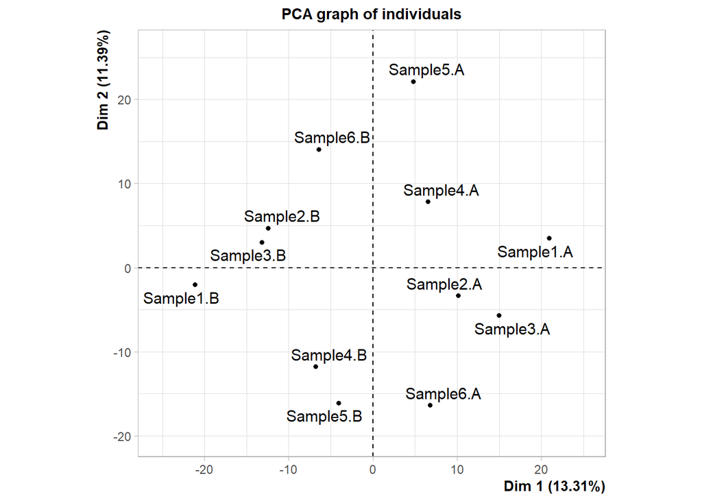

```r
pca <- PCA(data.4[,2:ncol(data.4)], scale.unit=TRUE, ncp=5,graph = FALSE)

plot(pca, choix = "ind")
```

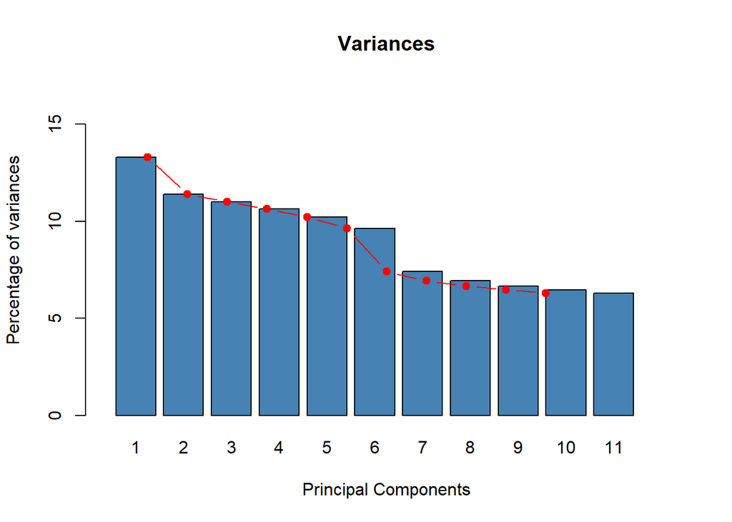

```r
eigenvalues <- pca$eig

barplot(eigenvalues[, 2], names.arg=1:nrow(eigenvalues),
       main = "Variances",
       xlab = "Principal Components",
       ylab = "Percentage of variances",
       xlim=c(0,14), ylim=c(0,17),
       col ="steelblue")
lines(x = 1:nrow(eigenvalues), eigenvalues[, 2],
      type="b", pch=19, col = "red")
```

Extract the contribution of features to the PC1 (highest variance) and order it according to the feature which has the most contribution for the partition to the feature that has the least contribution.

```r
var<-as.data.frame(pca$var$contrib)

dim1 <- var[order(-var$Dim.1),]

dim1_positions<-(rownames(dim1)[1:500])

head(dim1)
```

```
##               Dim.1        Dim.2       Dim.3        Dim.4        Dim.5
## chre-8367 0.5388209 2.649725e-05 0.108542329 3.231837e-05 6.731161e-03
## chrc-1819 0.5278772 3.293323e-03 0.019181180 8.245815e-03 9.179907e-02
## chrh-3439 0.5207447 1.353730e-01 0.002456578 3.045481e-03 6.872734e-06
## chrg-9317 0.4747136 4.838796e-02 0.098884559 5.572487e-03 1.035404e-02
## chrh-7906 0.4611694 2.283057e-03 0.027715675 5.072825e-02 3.165100e-02
## chre-7102 0.4583639 9.823525e-02 0.025785541 2.138811e-04 4.269626e-05
```

variable that consist of the top 500 feature that has the the most contribution in determining PC1 variance.

```r
head(dim1_positions)
```

```
## [1] "chre-8367" "chrc-1819" "chrh-3439" "chrg-9317" "chrh-7906" "chre-7102"
```

scale the data

```r
scale_data<- scale(data.4[,2:ncol(data.4)],center=TRUE,scale=TRUE)

summary(scale_data[,2:10])
```

```
##     chra-167          chra-249           chra-288          chra-329
##  Min.   :-1.6300   Min.   :-1.03555   Min.   :-1.3611   Min.   :-1.3440
##  1st Qu.:-0.7568   1st Qu.:-0.93199   1st Qu.:-0.5204   1st Qu.:-0.7680
##  Median : 0.1164   Median : 0.06904   Median : 0.0000   Median :-0.0384
##  Mean   : 0.0000   Mean   : 0.00000   Mean   : 0.0000   Mean   : 0.0000
##  3rd Qu.: 0.8586   3rd Qu.: 0.55229   3rd Qu.: 0.6005   3rd Qu.: 0.7296
##  Max.   : 1.1643   Max.   : 1.58784   Max.   : 1.8415   Max.   : 1.4208
##     chra-633          chra-641          chra-674          chra-680
##  Min.   :-1.2687   Min.   :-1.0791   Min.   :-1.4608   Min.   :-0.8935
##  1st Qu.:-0.6952   1st Qu.:-0.9110   1st Qu.:-0.6506   1st Qu.:-0.6382
##  Median :-0.2259   Median :-0.2383   Median :-0.1350   Median :-0.3404
##  Mean   : 0.0000   Mean   : 0.0000   Mean   : 0.0000   Mean   : 0.0000
##  3rd Qu.: 0.7125   3rd Qu.: 0.7708   3rd Qu.: 0.4542   3rd Qu.: 0.1489
##  Max.   : 1.6510   Max.   : 1.4435   Max.   : 1.7800   Max.   : 2.5104
##     chra-828
##  Min.   :-1.29464
##  1st Qu.:-0.79473
##  Median : 0.01282
##  Mean   : 0.00000
##  3rd Qu.: 0.78191
##  Max.   : 1.62791
```

Preprocess the dataset and assign variables for univariate analysis.

```r
data_stat<-as.data.frame(scale_data[,2:ncol(scale_data)])

number.of.samples<-ncol(data_stat)

input<-t(data_stat)

# Create a output

p.value.vector <- c()

# Assign it to a list

p.value.list <- numeric(number.of.samples)

head(input)
```

```
##           Sample1.A   Sample1.B  Sample2.A  Sample2.B   Sample3.A  Sample3.B
## chra-167  0.1164266  0.11642656 -0.2328531  0.8149859  0.98962579  1.1642656
## chra-249  1.5878383 -0.89747383  0.3451822  1.1736196  0.06903645 -1.0355467
## chra-288  0.2401922  0.08006408  0.7205767 -1.3610893 -1.36108931  1.8414738
## chra-329  0.6527935  0.95999050 -1.3439867 -1.1903882 -0.88319126  0.3455966
## chra-633 -0.4344766 -0.01737906 -0.4344766  1.0253648  1.65101104 -0.8515741
## chra-641 -0.7427843 -0.91096182 -1.0791394 -0.2382516  0.60263628  1.4435241
##           Sample4.A  Sample4.B   Sample5.A  Sample5.B   Sample6.A   Sample6.B
## chra-167 -1.2806922  0.9896258  0.81498595 -1.2806922 -0.58213282 -1.62997190
## chra-249 -0.8974738 -1.0355467  0.20710934 -1.0355467  1.44976541  0.06903645
## chra-288 -0.2401922  1.0408330 -0.08006408 -1.3610893 -0.08006408  0.56044854
## chra-329 -0.7295928  1.4207859  1.42078595 -0.7295928 -0.42239582  0.49919506
## chra-633  1.4424623 -0.6430254  0.60826723 -1.2686716  0.19116970 -1.26867164
## chra-641  1.2753465 -0.9109618 -0.23825155  0.4344587 -1.07913939  1.44352412
```

number of features

```r
features <-1:nrow(input)
```

conduct wilcoxon test

```r
for (i in features) {
  north <- unlist(input[i, 1:6])
  south <- unlist(input[i, 6:12])
  wilcox.test.i <- wilcox.test(north, south,
                               mu=0,
                               alt="two.sided",
                               p.adjust.method="BH",
                               paired=F,
                               conf.int=F,
                               conf.level=0.95,
                               exact=F
  )
  p.value.list[i] <- wilcox.test.i["p.value"]
}
```

create a dataframe to store the p values.

```r
data.list.df <- paste(rownames(input))

data.list.df<-as.data.frame(data.list.df)

p.value_data<- data.frame(matrix(unlist(p.value.list ), nrow=length(p.value.list ), byrow=TRUE))

colnames(p.value_data)<-"p.value"
```

Binding chromosome position list and pvalue to create dataframe. Further extract the chromosome positions having p value which are less than or equal to 0.05.

```r
wilcox.test.results <- cbind(data.list.df, p.value_data)

wilcox.test.results_top<-wilcox.test.results[which(wilcox.test.results[,2] <= 0.05),]

print(wilcox.test.results_top)
```

```
##      data.list.df     p.value
## 11       chra-983 0.044907778
## 200       chrc-42 0.020639940
## 462     chre-6076 0.025564506
## 469     chre-6755 0.043433963
## 524     chrf-2792 0.021359068
## 567     chrf-6883 0.030482500
## 614     chrg-1823 0.036208901
## 635     chrg-3649 0.017306066
## 640     chrg-4131 0.044907778
## 650     chrg-4833 0.017620358
## 743     chrh-4864 0.017462921
## 769     chrh-7837 0.037523900
## 875     chri-7617 0.011824155
## 995     chrj-9452 0.044612159
## 1000     chrk-120 0.044612159
## 1008     chrk-705 0.007447365
```

Find the intersecting chromosome position between the ones which were present in PC1 (showing highest efficiency in determining the variance between the sample) and the significant chromosome position identified by the univariate analysis - wilcoxon method.

```r
pca_wilcox<-intersect(wilcox.test.results_top$data.list.df,dim1_positions)

print(pca_wilcox)
```

```
## [1] "chre-6076" "chrf-2792" "chrg-1823" "chrh-7837" "chri-7617" "chrk-705"
```

There are 6 chromosome position that are found to be common in both the PCA and Wilcoxon test and these 6 chromosome position is used to build a heatmap to visualize how the samples are being correlated to these identified position between north and south location.

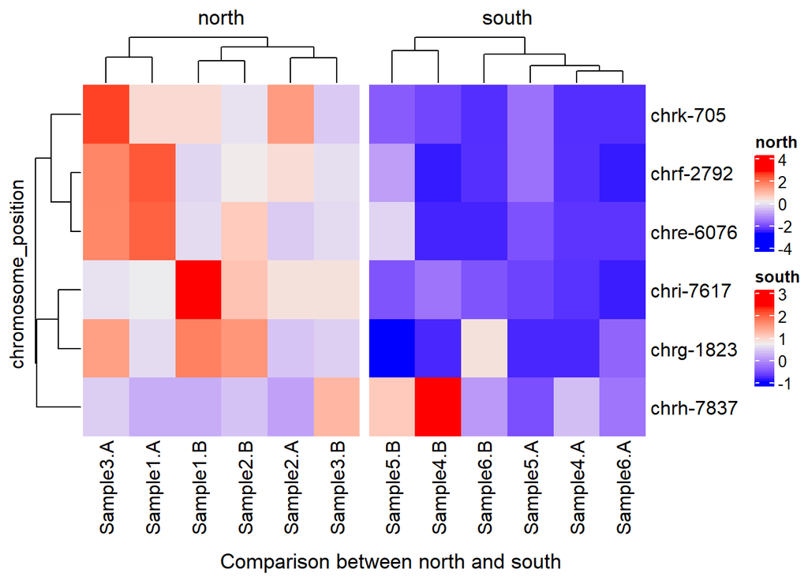

```r
data_heatmap<-input[rownames(input) %in% pca_wilcox,]

ht1 = Heatmap(data_heatmap[,1:6], name = "north", row_title = "", column_title = "north")
ht2 = Heatmap(data_heatmap[,7:12], name = "south", row_title = "", column_title = "south")

ht_list = ht1 + ht2

draw(ht_list, row_title = "chromosome_position", row_title_gp = gpar(col = "black"),
     column_title = "Comparison between north and south", column_title_side = "bottom")
```

## Result

Chromosome position for differentiating the samples between the location (north vs south) are “chre-6076”, “chrf-2792” “chrg-1823”,“chri-7617”, “chrk-705”.

## Discussion

From the visualization we can see that chromosome position - chrk-705,chrf-2792,chre-6076,chri7617 and chrg1823 are highly efficient in differentiating the samples between the location. These 5 genes are negatively correlated to the south location and positively correlated in some of the north samples while moderately correlated to the remaining north samples.

These chromosome positions are believed to be able to different the samples from the regions they were obtained from.